# Case study

Junyuan Zhang

10/21/2021

# Introduction

In this case study, we want to investigate the association between alcohol level of ”Vinho Verde” wine and physio-chemical information. The predictor included in our full model are:

1. fixed acidity
2. volatile acidity
3. citric acid
4. residual sugar
5. chlorides
6. free sulfur dioxide
7. total sulfur dioxide
8. density
9. pH
10. sulphates

```r
library(ggplot2)
library(faraway)
redwines <- read.csv("redwines.csv", header = TRUE)
dim(redwines)
```

```
## [1] 1599   12
```

```r
redwines = redwines[, - 12] #drop the quality
redwines.full = lm(alcohol ~.,data = redwines)
summary(redwines.full)
```

```
##
## Call:
## lm(formula = alcohol ~ ., data = redwines)
##
## Residuals:
##      Min       1Q   Median       3Q      Max
## -2.07175 -0.39267 -0.04056  0.35396  2.44365
##
## Coefficients:
##                        Estimate Std. Error t value Pr(>|t|)
## (Intercept)           6.072e+02  1.308e+01  46.419  < 2e-16 ***
## fixed.acidity         5.324e-01  2.064e-02  25.796  < 2e-16 ***
## volatile.acidity      3.608e-01  1.144e-01   3.154 0.001638 **
## citric.acid           8.306e-01  1.379e-01   6.024 2.11e-09 ***
## residual.sugar        2.844e-01  1.229e-02  23.135  < 2e-16 ***
## chlorides            -1.462e+00  3.956e-01  -3.696 0.000227 ***
## free.sulfur.dioxide  -2.143e-03  2.057e-03  -1.042 0.297517
## total.sulfur.dioxide -2.296e-03  6.881e-04  -3.336 0.000868 ***
## density              -6.174e+02  1.342e+01 -45.998  < 2e-16 ***
## pH                    3.762e+00  1.551e-01  24.263  < 2e-16 ***
## sulphates             1.247e+00  1.037e-01  12.020  < 2e-16 ***
## ---
## Signif. codes:  0 '***' 0.001 '**' 0.01 '*' 0.05 '.' 0.1 ' ' 1
##
## Residual standard error: 0.614 on 1588 degrees of freedom
## Multiple R-squared:  0.6701, Adjusted R-squared:  0.668
## F-statistic: 322.5 on 10 and 1588 DF,  p-value: < 2.2e-16
```

We first fit the full model that contains all predictors. By looking at the Anova table, we found that the free sulfur dioxide predictor is insignificant since its p-value is much greater than 0.05. Thus we need consider drop this predictor

```r
redwines.reduced = lm(alcohol ~ fixed.acidity +
    volatile.acidity + citric.acid + residual.sugar +
    chlorides + total.sulfur.dioxide +
    density + pH + sulphates, data = redwines) # drop free_sulfur_dioxide

anova(redwines.reduced, redwines.full)
```

```
## Analysis of Variance Table
##
## Model 1: alcohol ~ fixed.acidity + volatile.acidity + citric.acid + residual.sugar +
##     chlorides + total.sulfur.dioxide + density + pH + sulphates
## Model 2: alcohol ~ fixed.acidity + volatile.acidity + citric.acid + residual.sugar +
##     chlorides + free.sulfur.dioxide + total.sulfur.dioxide +
##     density + pH + sulphates
##   Res.Df    RSS Df Sum of Sq     F Pr(>F)
## 1   1589 599.11
## 2   1588 598.70  1   0.40944 1.086 0.2975
```

```r
# don't reject null so reduced model is better
```

We fit a new model called redwines.reduced above without the free sulfur dioxide. We made the hyphothesis that $H_0 :$ reduced model is better, $H_a:$ full model is needed. Also, by looking the anova table above, the $p$ value is larger than 0.05. Thus we do not reject the null hypothesis that reduced model is better. We confirm that can drop free sulfur dioxide predictor. The reduced model will be used in following analysis

```r
#B outlier test
summary(redwines.reduced)
```

```
##
## Call:
## lm(formula = alcohol ~ fixed.acidity + volatile.acidity + citric.acid +
##     residual.sugar + chlorides + total.sulfur.dioxide + density +
##     pH + sulphates, data = redwines)
##
## Residuals:
##      Min       1Q   Median       3Q      Max
## -2.06145 -0.39706 -0.03917  0.34928  2.44848
##
## Coefficients:
##                        Estimate Std. Error t value Pr(>|t|)
## (Intercept)           6.059e+02  1.302e+01  46.535  < 2e-16 ***
## fixed.acidity         5.300e-01  2.051e-02  25.846  < 2e-16 ***
## volatile.acidity      3.809e-01  1.128e-01   3.377 0.000749 ***
## citric.acid           8.548e-01  1.359e-01   6.289 4.12e-10 ***
## residual.sugar        2.827e-01  1.219e-02  23.198  < 2e-16 ***
## chlorides            -1.487e+00  3.949e-01  -3.766 0.000172 ***
## total.sulfur.dioxide -2.775e-03  5.123e-04  -5.416 7.02e-08 ***
## density              -6.160e+02  1.335e+01 -46.125  < 2e-16 ***
## pH                    3.739e+00  1.534e-01  24.369  < 2e-16 ***
## sulphates             1.242e+00  1.036e-01  11.984  < 2e-16 ***
## ---
## Signif. codes:  0 '***' 0.001 '**' 0.01 '*' 0.05 '.' 0.1 ' ' 1
##
## Residual standard error: 0.614 on 1589 degrees of freedom
## Multiple R-squared:  0.6699, Adjusted R-squared:  0.668
## F-statistic: 358.2 on 9 and 1589 DF,  p-value: < 2.2e-16
```

The reduced model above now has all predictors significant

```r
n = dim(redwines)[1]
p = 10 # droped 1
critical = qt(.05/(2*n), n-p-1)
redwines.resid = rstudent(redwines.reduced)

sort(abs(redwines.resid), decreasing = TRUE)[1:10]
```

```
##      652      560      565      396      354      557      559      494
## 4.038199 4.018534 4.018534 3.952545 3.858127 3.694477 3.694477 3.670237
##      500      268
## 3.670237 3.455404
```

```r
# no outliers
```

```r
# high leverage
lev = lm.influence(redwines.reduced)$hat
head(lev)
```

```
##           1           2           3           4           5           6
## 0.003515642 0.005286754 0.002807848 0.004520270 0.003515642 0.003660375
```

```r
leverages = lev[lev>(2*p/n)]
head(leverages)
```

```
##         14         18         20         34         39         43
## 0.02545301 0.02737606 0.02204734 0.02383297 0.01514653 0.02155009
```

```r
length(leverages) / n # 7 percent of points are high leverage
```

```
## [1] 0.07066917
```

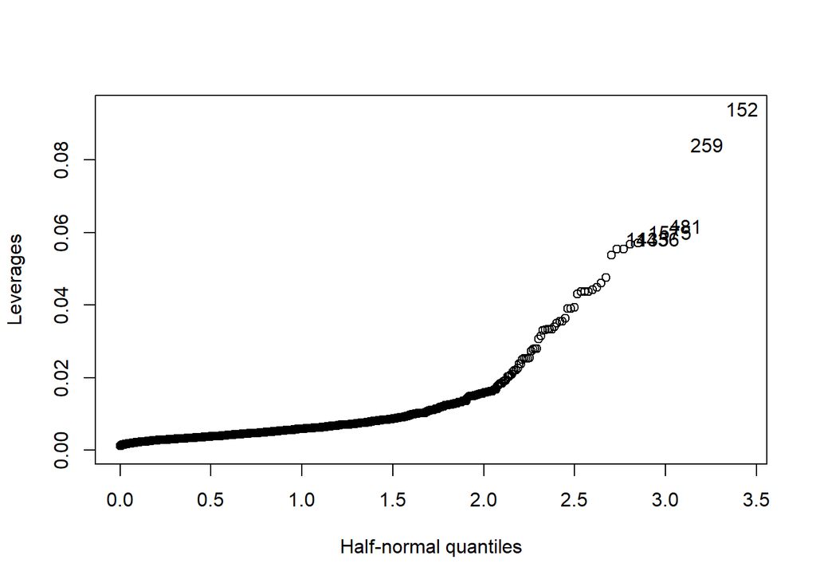

```r
halfnorm(lev, 6, labs=as.character(1:length(lev)), ylab = "Leverages")
```

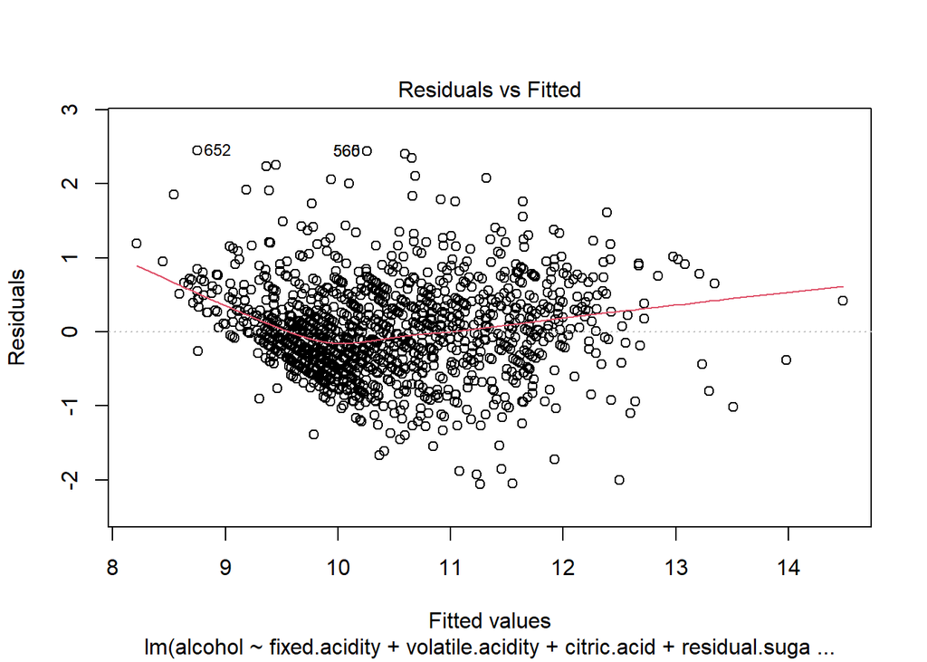

```r
# constant variance
plot(redwines.reduced, which =1)
```

```r
library(lmtest)
bptest(redwines.reduced)
```

```
##
##  studentized Breusch-Pagan test
##
## data:  redwines.reduced
## BP = 169.31, df = 9, p-value < 2.2e-16
```

```r
# reject const variance
```

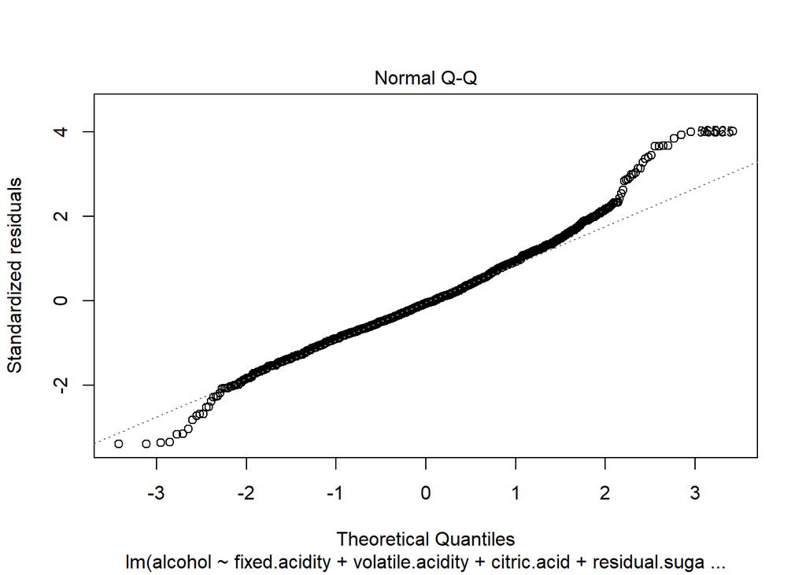

```r
# normality
plot(redwines.reduced, which =  2)
```

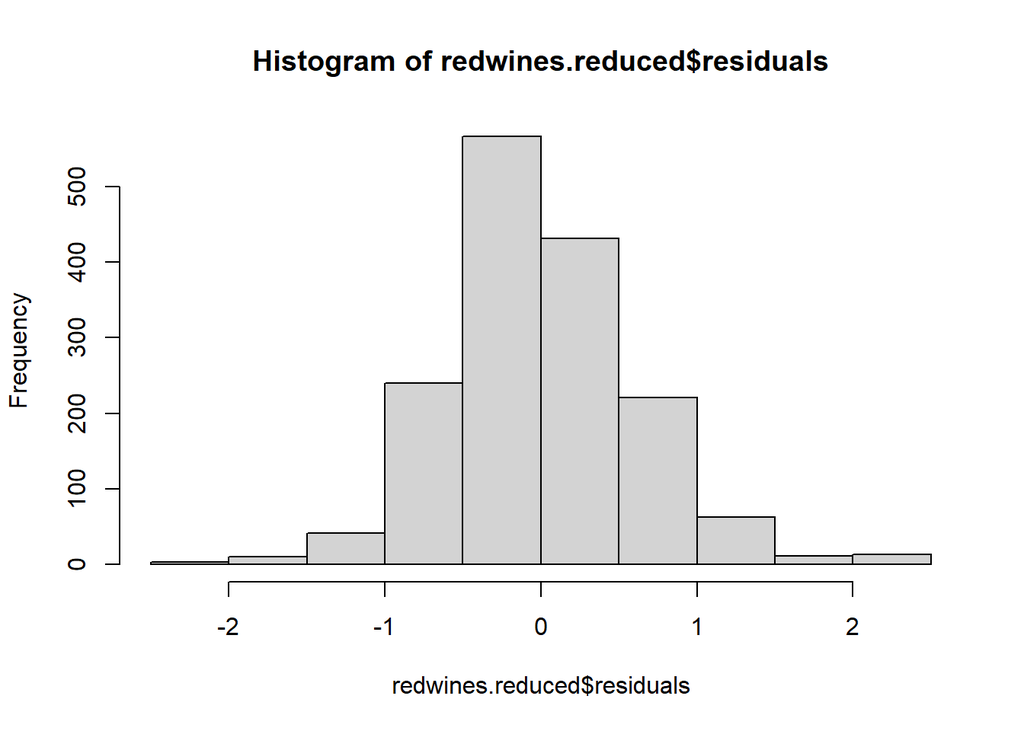

```r
hist(redwines.reduced$residuals)
```

```r
ks.test(residuals(redwines.reduced), y = pnorm)
```

```
##
##  One-sample Kolmogorov-Smirnov test
##
## data:  residuals(redwines.reduced)
## D = 0.14307, p-value < 2.2e-16
## alternative hypothesis: two-sided
```

```r
# reject normality
```

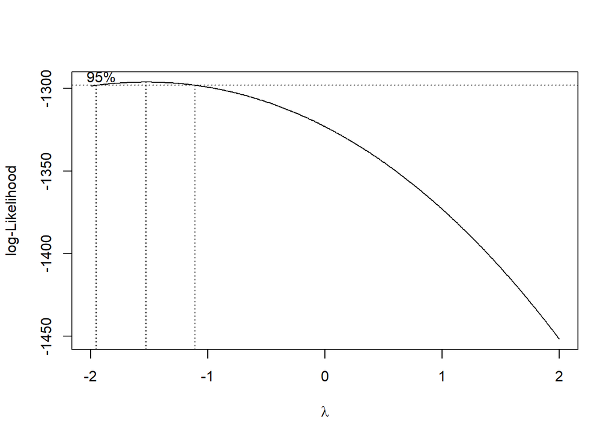

```r
# box transformation

library(MASS)
redwines.boxcox = boxcox(redwines.reduced, lambda=seq(-2, 2, length=400))
```

```r
lambda = redwines.boxcox$x[redwines.boxcox$y == max(redwines.boxcox$y)]

redwines$alcohol.new = ((redwines$alcohol)^lambda - 1) / lambda

redwines.transform = lm(alcohol.new ~ fixed.acidity +
    volatile.acidity + citric.acid + residual.sugar +
    chlorides + total.sulfur.dioxide +
    density + pH + sulphates, data = redwines)

summary(redwines.transform)
```

```
##
## Call:
## lm(formula = alcohol.new ~ fixed.acidity + volatile.acidity +
##     citric.acid + residual.sugar + chlorides + total.sulfur.dioxide +
##     density + pH + sulphates, data = redwines)
##
## Residuals:
##        Min         1Q     Median         3Q        Max
## -0.0056710 -0.0010157 -0.0000064  0.0010000  0.0064187
##
## Coefficients:
##                        Estimate Std. Error t value Pr(>|t|)
## (Intercept)           2.080e+00  3.349e-02  62.118  < 2e-16 ***
## fixed.acidity         1.307e-03  5.274e-05  24.786  < 2e-16 ***
## volatile.acidity      9.860e-04  2.901e-04   3.399 0.000692 ***
## citric.acid           2.066e-03  3.496e-04   5.908 4.22e-09 ***
## residual.sugar        6.819e-04  3.135e-05  21.752  < 2e-16 ***
## chlorides            -4.683e-03  1.016e-03  -4.610 4.34e-06 ***
## total.sulfur.dioxide -8.419e-06  1.318e-06  -6.389 2.19e-10 ***
## density              -1.495e+00  3.435e-02 -43.531  < 2e-16 ***
## pH                    9.259e-03  3.946e-04  23.461  < 2e-16 ***
## sulphates             3.190e-03  2.665e-04  11.970  < 2e-16 ***
## ---
## Signif. codes:  0 '***' 0.001 '**' 0.01 '*' 0.05 '.' 0.1 ' ' 1
##
## Residual standard error: 0.001579 on 1589 degrees of freedom
## Multiple R-squared:  0.6509, Adjusted R-squared:  0.649
## F-statistic: 329.3 on 9 and 1589 DF,  p-value: < 2.2e-16
```

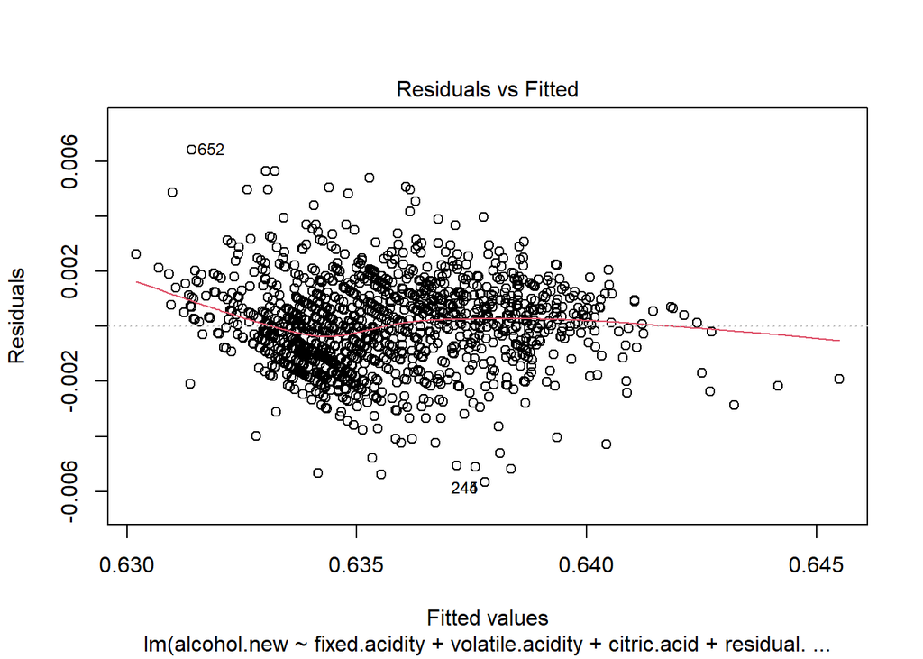

```r
plot(redwines.transform, which = 1)
```

```r
bptest(redwines.transform)
```

```
##
##  studentized Breusch-Pagan test
##
## data:  redwines.transform
## BP = 184.17, df = 9, p-value < 2.2e-16
```

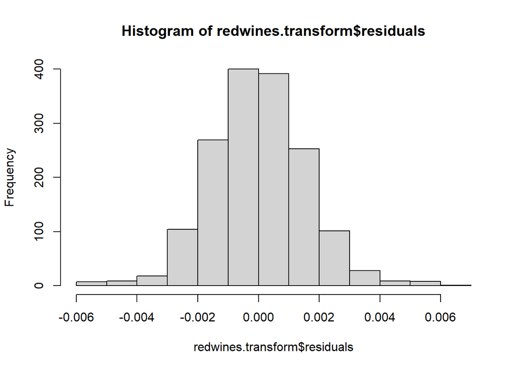

```r
hist(redwines.transform$residuals)
```

```r
ks.test(residuals(redwines.transform), y=pnorm)
```

```
##
##  One-sample Kolmogorov-Smirnov test
##
## data:  residuals(redwines.transform)
## D = 0.49774, p-value < 2.2e-16
## alternative hypothesis: two-sided
```

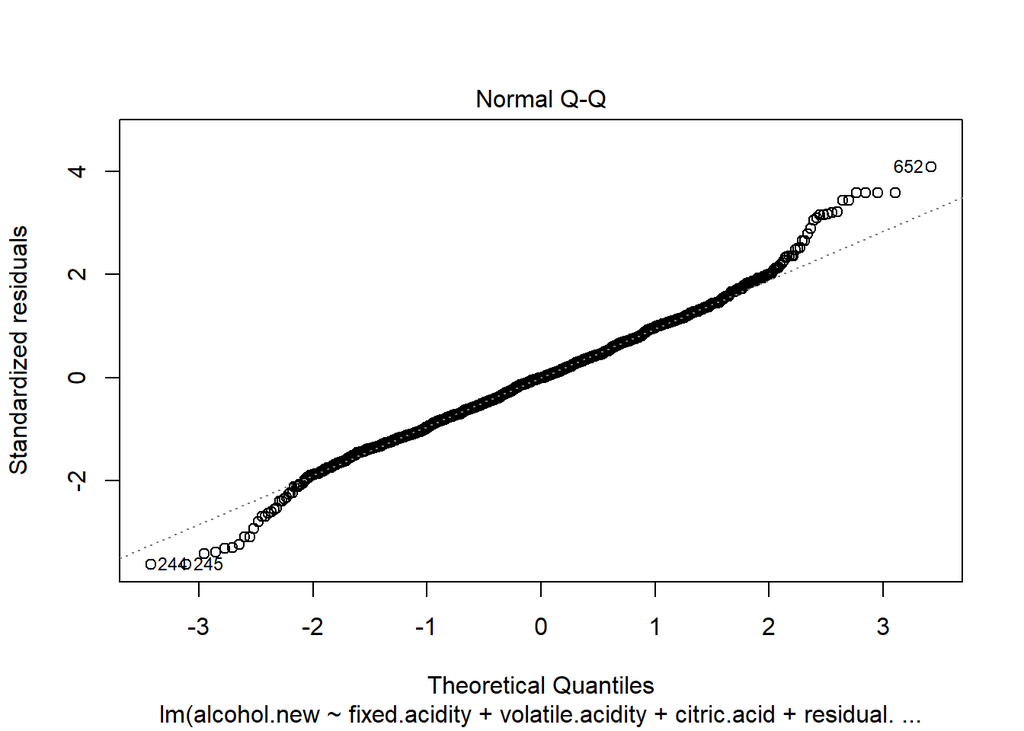

```r
plot(redwines.transform, which=2)
```